# Project BDA

2702305576_Grace

2025-01-02

# California Housing Prices

- Number of Rows: 20,640
- Number of Columns: 10
- Source: [California Housing Prices Dataset](https://www.kaggle.com/datasets/camnugent/california-housing-prices)

```r
library(rjags)
library(coda)
library(mice)
```

### Dataset Overview

This dataset contains housing data for districts in California, including attributes such as location, income levels, and housing characteristics. The main objective is to analyze how these factors influence house pricing.

```r
data <- read.csv('housing.csv')
head(data, 5)
```

|  | longitude | latitude | housing_median_age | total_rooms | total_bedrooms | population | households | median_income | median_house_value | ocean_proximity |
| --- | --- | --- | --- | --- | --- | --- | --- | --- | --- | --- |
| 1 | -122.23 | 37.88 | 41 | 880 | 129 | 322 | 126 | 8.3252 | 452600 | NEAR BAY |
| 2 | -122.22 | 37.86 | 21 | 7099 | 1106 | 2401 | 1138 | 8.3014 | 358500 | NEAR BAY |
| 3 | -122.24 | 37.85 | 52 | 1467 | 190 | 496 | 177 | 7.2574 | 352100 | NEAR BAY |
| 4 | -122.25 | 37.85 | 52 | 1274 | 235 | 558 | 219 | 5.6431 | 341300 | NEAR BAY |
| 5 | -122.25 | 37.85 | 52 | 1627 | 280 | 565 | 259 | 3.8462 | 342200 | NEAR BAY |

```r
# Checking for missing value
sum(is.na(data))
```

```
## [1] 207
```

```r
sum(is.na(df))
```

```
## [1] 0
```

```r
str(df)
```

```
## 'data.frame':    20640 obs. of  10 variables:
##  $ longitude         : num  -122 -122 -122 -122 -122 ...
##  $ latitude          : num  37.9 37.9 37.9 37.9 37.9 ...
##  $ housing_median_age: num  41 21 52 52 52 52 52 52 42 52 ...
##  $ total_rooms       : num  880 7099 1467 1274 1627 ...
##  $ total_bedrooms    : num  129 1106 190 235 280 ...
##  $ population        : num  322 2401 496 558 565 ...
##  $ households        : num  126 1138 177 219 259 ...
##  $ median_income     : num  8.33 8.3 7.26 5.64 3.85 ...
##  $ median_house_value: num  452600 358500 352100 341300 342200 ...
##  $ ocean_proximity   : Factor w/ 5 levels "<1H OCEAN","INLAND",..: 4 4 4 4 4 4 4 4 4 4 ...
```

### Column Descriptions:

1. **longitude**
   - Longitude coordinate of the district, representing its geographical location (Float).
2. **latitude**
   - Latitude coordinate of the district, representing its geographical location (Float).
3. **housing_median_age**
   - Median age of houses in the district. Used to approximate the age of housing stock (Float).
4. **total_rooms**
   - Total count of rooms across all houses in the district (Integer).
5. **total_bedrooms**
   - Total count of bedrooms across all houses in the district. May contain missing values (Float).
6. **population**
   - Total number of residents in the district (Integer).
7. **households**
   - Total number of households in the district, where each household represents a group of people living in the same housing unit (Integer).
8. **median_income**
   - Median household income in the district, scaled between ~0.5 and ~15 (Float).
9. **median_house_value**
   - Median house price in the district, expressed in US dollars (Float). This serves as the target variable.
10. **ocean_proximity**
    - Categorical feature indicating the district’s distance to the ocean, with values like:
      - **<1H OCEAN**: Less than one hour from the ocean.
      - **INLAND**: Located inland.
      - **NEAR OCEAN**: Close to the ocean.
      - **NEAR BAY**: Near the bay area.
      - **ISLAND**: Island region.

```r
summary(df)
```

```
##    longitude         latitude     housing_median_age  total_rooms
##  Min.   :-124.3   Min.   :32.54   Min.   : 1.00      Min.   :    2
##  1st Qu.:-121.8   1st Qu.:33.93   1st Qu.:18.00      1st Qu.: 1448
##  Median :-118.5   Median :34.26   Median :29.00      Median : 2127
##  Mean   :-119.6   Mean   :35.63   Mean   :28.64      Mean   : 2636
##  3rd Qu.:-118.0   3rd Qu.:37.71   3rd Qu.:37.00      3rd Qu.: 3148
##  Max.   :-114.3   Max.   :41.95   Max.   :52.00      Max.   :39320
##  total_bedrooms     population      households     median_income
##  Min.   :   1.0   Min.   :    3   Min.   :   1.0   Min.   : 0.4999
##  1st Qu.: 296.0   1st Qu.:  787   1st Qu.: 280.0   1st Qu.: 2.5634
##  Median : 435.0   Median : 1166   Median : 409.0   Median : 3.5348
##  Mean   : 537.9   Mean   : 1425   Mean   : 499.5   Mean   : 3.8707
##  3rd Qu.: 647.0   3rd Qu.: 1725   3rd Qu.: 605.0   3rd Qu.: 4.7432
##  Max.   :6445.0   Max.   :35682   Max.   :6082.0   Max.   :15.0001
##  median_house_value   ocean_proximity
##  Min.   : 14999     <1H OCEAN :9136
##  1st Qu.:119600     INLAND    :6551
##  Median :179700     ISLAND    :   5
##  Mean   :206856     NEAR BAY  :2290
##  3rd Qu.:264725     NEAR OCEAN:2658
##  Max.   :500001
```

```r
df <- as.matrix(df)
Y <- as.numeric(price)
X <- cbind(long, lat, age, room, bedroom, pop, household, income, price)
names <- c("Intercept", "Longitude", "Latitude", "Age", "Room", "Bedroom", "Population", "Household", "Income", "Price")
cor(X)
```

```
##                  long         lat         age        room      bedroom
## long       1.00000000 -0.92466443 -0.10819681  0.04456798  0.068358801
## lat       -0.92466443  1.00000000  0.01117267 -0.03609960 -0.066169120
## age       -0.10819681  0.01117267  1.00000000 -0.36126220 -0.320547306
## room       0.04456798 -0.03609960 -0.36126220  1.00000000  0.930084573
## bedroom    0.06835880 -0.06616912 -0.32054731  0.93008457  1.000000000
## pop        0.09977322 -0.10878475 -0.29624424  0.85712597  0.877837647
## household  0.05531009 -0.07103543 -0.30291601  0.91848449  0.979773178
## income    -0.01517587 -0.07980913 -0.11903399  0.19804965 -0.008010765
## price     -0.04596662 -0.14416028  0.10562341  0.13415311  0.050602620
##                    pop   household       income       price
## long       0.099773223  0.05531009 -0.015175865 -0.04596662
## lat       -0.108784747 -0.07103543 -0.079809127 -0.14416028
## age       -0.296244240 -0.30291601 -0.119033990  0.10562341
## room       0.857125973  0.91848449  0.198049645  0.13415311
## bedroom    0.877837647  0.97977318 -0.008010765  0.05060262
## pop        1.000000000  0.90722227  0.004834346 -0.02464968
## household  0.907222266  1.00000000  0.013033052  0.06584265
## income     0.004834346  0.01303305  1.000000000  0.68807521
## price     -0.024649679  0.06584265  0.688075208  1.00000000
```

I am using median_income, latitude, and total_rooms as the predictors for house pricing, with median_house_value being the target variable.

```r
# JAGS Model Specification
model_code <- "
model {
  for (i in 1:N) {
    Y[i] ~ dnorm(mu[i], tau)
    mu[i] <- beta0 + beta1 * X1[i] + beta2 * X2[i] + beta3 * X3[i]
  }
  beta0 ~ dnorm(0, 0.01)
  beta1 ~ dnorm(0, 0.01)
  beta2 ~ dnorm(0, 0.01)
  beta3 ~ dnorm(0, 0.01)
  tau <- 1 / sigma2
  sigma2 ~ dgamma(2, 0.1)
}
"
```

```r
jags_data <- list(
  N = nrow(X),
  Y = Y,
  X1 = X[, 8],  # Income
  X2 = X[, 2],  # Lat
  X3 = X[, 4]   # Room
)
```

```r
model <- jags.model(textConnection(model_code), data = jags_data, n.chains = 3)
update(model, 1000)
```

```r
samples <- coda.samples(model, c("beta0", "beta1", "beta2", "beta3", "sigma2"), n.iter = 10000)
```

## Output Posterior

### Empirical and Quantiles

```r
summary(samples)
```

```
##
## Iterations = 2001:12000
## Thinning interval = 1
## Number of chains = 3
## Sample size per chain = 10000
##
## 1. Empirical mean and standard deviation for each variable,
##    plus standard error of the mean:
##
##             Mean        SD  Naive SE Time-series SE
## beta0  2.065e+02 9.995e+00 5.770e-02      6.721e-02
## beta1  7.882e+03 6.631e+01 3.828e-01      6.615e+00
## beta2  4.271e+03 5.122e+00 2.957e-02      4.828e-01
## beta3  7.783e+00 3.043e-02 1.757e-04      2.286e-03
## sigma2 3.421e+07 3.247e+05 1.875e+03      3.542e+04
##
## 2. Quantiles for each variable:
##
##             2.5%       25%       50%       75%     97.5%
## beta0  1.870e+02 1.998e+02 2.065e+02 2.132e+02 2.261e+02
## beta1  7.859e+03 7.871e+03 7.877e+03 7.884e+03 7.897e+03
## beta2  4.268e+03 4.271e+03 4.272e+03 4.273e+03 4.276e+03
## beta3  7.746e+00 7.773e+00 7.785e+00 7.798e+00 7.821e+00
## sigma2 3.421e+07 3.423e+07 3.424e+07 3.425e+07 3.426e+07
```

### Interpretation

The residual variance, sigma2, is estimated at 34,240,000, indicating substantial variability in median house prices not explained by the predictors. This is expected since I am only using three predictors: median_income, latitude, and total_rooms.

- Median Income (beta1), the most influential predictor. Districts with higher median household income are strongly associated with higher median house prices. The posterior mean is 7877, reflecting a significant positive relationship.
- Latitude (beta2), latitude is positively associated with median house prices (posterior mean: 4272). This could reflect regional differences in housing demand or geographic desirability.
- Total Rooms (beta3), total rooms have a small but consistent positive effect (posterior mean: 7.785). While significant, its contribution is modest, possibly reflecting a limited role compared to other unmodeled housing characteristics.
- Residual Variance (sigma2), the large variance (34,240,000) since I am only using three predictors, this suggests other factors, which are not captured by the current model. But as expected.

## Model Evaluation

### Convergence Diagnostics

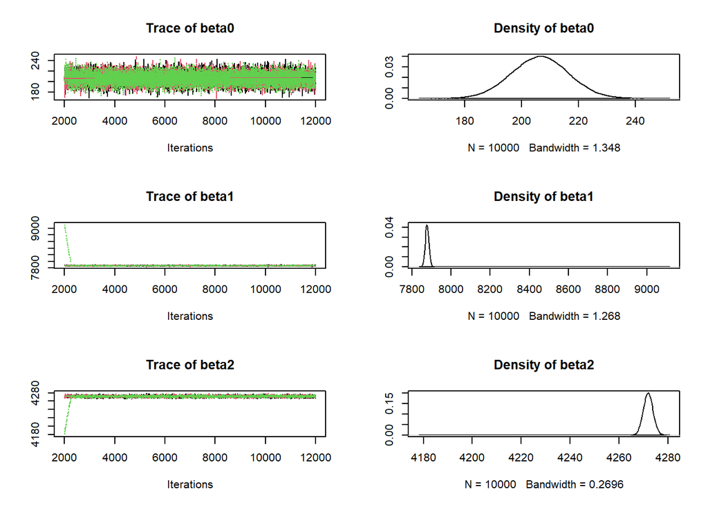

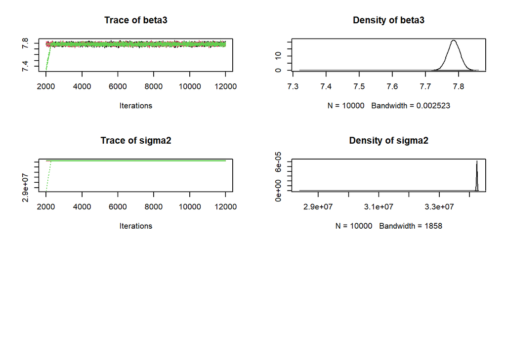

```r
plot(samples)
```

### Gelman-Rubin Diagnostic

```r
gelman_diag <- gelman.diag(samples)
gelman_diag
```

```
## Potential scale reduction factors:
##
##        Point est. Upper C.I.
## beta0           1          1
## beta1           1          1
## beta2           1          1
## beta3           1          1
## sigma2          1          1
##
## Multivariate psrf
##
## 1
```

The Gelman Rubin Diagnostic (PSRF) confirm that the MCMC sampler has fully converged for all parameters. The posterior samples are reliable, and the model results can be confidently interpreted.

### Autocorrelation diagnostics

```r
acf_plot <- autocorr.diag(samples)
acf_plot
```

```
##              beta0     beta1     beta2     beta3    sigma2
## Lag 0  1.000000000 1.0000000 1.0000000 1.0000000 1.0000000
## Lag 1  0.068272569 0.6345152 0.7691105 0.6978821 0.4851851
## Lag 5  0.010039301 0.3255498 0.3683511 0.3185488 0.3246712
## Lag 10 0.006676974 0.3094966 0.3063371 0.2687490 0.3042477
## Lag 50 0.005339891 0.2434602 0.2121975 0.1954212 0.2380279
```

### ESS

```r
ESS <- effectiveSize(samples)
ESS
```

```
##     beta0     beta1     beta2     beta3    sigma2
## 23451.729  7497.051  4399.996  5405.829 12209.972
```

- All parameters have sufficient ESS for reliable inference, with beta0 and sigma2 having the highest values.
- Slightly lower ESS for beta2 and beta3, it shows their relatively higher autocorrelation but is still acceptable for most analyses.